# Trace points

June 23 2022

## Basic Usage

`geom_point_trace()` is similar to `ggplot2::geom_point()`, but also includes the ability to outline points of interest. This is particularly useful when working with dense datasets that are prone to overplotting. This geom accepts normal ggplot2 graphical parameters with some modifications. `fill` controls the color of each point, `color` controls the outline color, and `stroke` controls outline width, similar to how filled shapes are modified for other ggplot2 geoms. Additional parameters including `size`, `linetype`, and `alpha` are also accepted.

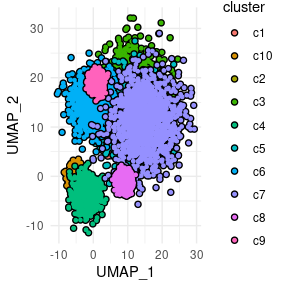

```r
library(ggplot2)
library(ggtrace)

p <- ggplot(
  clusters,
  aes(UMAP_1, UMAP_2, fill = cluster)
) +
  theme_minimal()

p +
  geom_point_trace(
    color    = "black",
    size     = 1,
    linetype = 1,
    alpha    = 1
  )
```

## Aesthetics

Like other ggplot2 geoms, variables can be mapped to aesthetic attributes to modify the outline appearance.

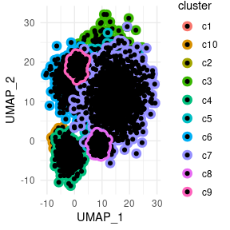

```r
ggplot(
  clusters,
  aes(UMAP_1, UMAP_2, color = cluster)
) +
  geom_point_trace(
    fill   = "black",
    stroke = 2
  ) +
  theme_minimal()
```

By specifying `group` within `aes()`, outlines can also be added when coloring with a continuous variable. This is useful for visualizing points that are lightly colored.

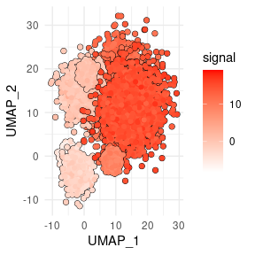

```r
p <- ggplot(
  clusters,
  aes(UMAP_1, UMAP_2, fill = signal, group = cluster)
) +
  theme_minimal()

p +
  geom_point_trace(stroke = 0.5) +
  scale_fill_gradient(low = "white", high = "red")
```

Aesthetics can be further modified using the ggplot2 `scale_*()` functions.

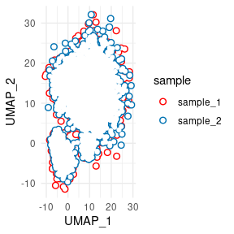

```r
p <- ggplot(
  clusters,
  aes(UMAP_1, UMAP_2, color = sample)
) +
  theme_minimal()

p +
  geom_point_trace(fill = "white") +
  scale_color_manual(values = c("red", "#0072B2"))
```

## Position

The “position” of the outline can be modified with the `trace_position` argument. This can be “all”, “bottom”, or a predicate selecting the points to outline. By default all groups are outlined.

To only add a single outline around all points plotted, set `trace_position` to “bottom”.

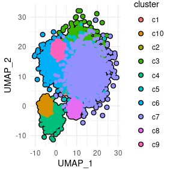

```r
p <- ggplot(
  clusters,
  aes(UMAP_1, UMAP_2, fill = cluster)
) +
  theme_minimal()

p +
  geom_point_trace(trace_position = "bottom")
```

A subset of data points can be highlighted by passing a predicate to `trace_position`. This must evaluate to `TRUE` or `FALSE` within the context of the input data.

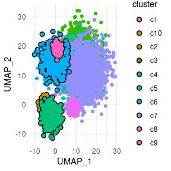

```r
p +
  geom_point_trace(trace_position = signal < 0)
```

The appearance of background points can be modified by passing a named list of parameters to `background_params`.

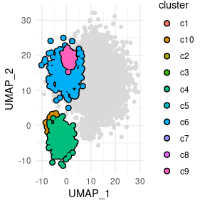

```r
p +
  geom_point_trace(
    trace_position    = signal < 0,
    background_params = list(color = NA, fill = "grey85")
  )
```

Outlines can be removed by setting `color` to `NA`.

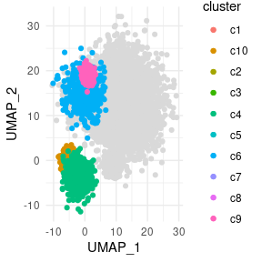

```r
p +
  geom_point_trace(
    trace_position    = signal < 0,
    color             = NA,
    background_params = list(color = NA, fill = "grey85")
  )
```